# BME 503: Computational Nueroengineering

# Long Term Mortality Prediction with a Backpropated Feedforward Neural Network

## Background

### Continuity of Care

Quality and level of care over a period of time.

### Population Health

Overall health outcome of a community of people.

## Long Term Health and Mortality

Looking at a patient's health after their discharge from the hospital.

What if we could know a patient's risk of dying up to one year after a hospital visit?

## Problem Statement

Physicians need a method to perdict long term mortality, up to one year in the future, to maintain continuity of care and increase overall population health.

## Data

Acquired from the MIMIC-III database, a dataset on ICU admissions compiled by MIT.

## Admissions

```python
admissions.head()
```

|  | ROW_ID | SUBJECT_ID | HADM_ID | ADMITTIME | DISCHTIME | DEATHTIME | ADMISSION_TYPE | ADMISSION_LOCATION | DISCHARGE_LOCATION | INSURANCE | LANGUAGE | RELIGION | MARITAL_STATUS | ETHNICITY | EDREGTIME | EDOUTTIME | DIAGNOSIS | HOSPITAL_EXPIRE_FLAG | HAS_CHARTEVENTS_DATA |
| --- | --- | --- | --- | --- | --- | --- | --- | --- | --- | --- | --- | --- | --- | --- | --- | --- | --- | --- | --- |
| 0 | 21 | 22 | 165315 | 2196-04-09 12:26:00 | 2196-04-10 15:54:00 | NaN | EMERGENCY | EMERGENCY ROOM ADMIT | DISC-TRAN CANCER/CHLDRN H | Private | NaN | UNOBTAINABLE | MARRIED | WHITE | 2196-04-09 10:06:00 | 2196-04-09 13:24:00 | BENZODIAZEPINE OVERDOSE | 0 | 1 |
| 1 | 22 | 23 | 152223 | 2153-09-03 07:15:00 | 2153-09-08 19:10:00 | NaN | ELECTIVE | PHYS REFERRAL/NORMAL DELI | HOME HEALTH CARE | Medicare | NaN | CATHOLIC | MARRIED | WHITE | NaN | NaN | CORONARY ARTERY DISEASE\CORONARY ARTERY BYPASS... | 0 | 1 |
| 2 | 23 | 23 | 124321 | 2157-10-18 19:34:00 | 2157-10-25 14:00:00 | NaN | EMERGENCY | TRANSFER FROM HOSP/EXTRAM | HOME HEALTH CARE | Medicare | ENGL | CATHOLIC | MARRIED | WHITE | NaN | NaN | BRAIN MASS | 0 | 1 |
| 3 | 24 | 24 | 161859 | 2139-06-06 16:14:00 | 2139-06-09 12:48:00 | NaN | EMERGENCY | TRANSFER FROM HOSP/EXTRAM | HOME | Private | NaN | PROTESTANT QUAKER | SINGLE | WHITE | NaN | NaN | INTERIOR MYOCARDIAL INFARCTION | 0 | 1 |
| 4 | 25 | 25 | 129635 | 2160-11-02 02:06:00 | 2160-11-05 14:55:00 | NaN | EMERGENCY | EMERGENCY ROOM ADMIT | HOME | Private | NaN | UNOBTAINABLE | MARRIED | WHITE | 2160-11-02 01:01:00 | 2160-11-02 04:27:00 | ACUTE CORONARY SYNDROME | 0 | 1 |

## Patients

```python
patients.head()
```

|  | ROW_ID | SUBJECT_ID | GENDER | DOB | DOD | DOD_HOSP | DOD_SSN | EXPIRE_FLAG |
| --- | --- | --- | --- | --- | --- | --- | --- | --- |
| 0 | 234 | 249 | F | 2075-03-13 00:00:00 | NaN | NaN | NaN | 0 |
| 1 | 235 | 250 | F | 2164-12-27 00:00:00 | 2188-11-22 00:00:00 | 2188-11-22 00:00:00 | NaN | 1 |
| 2 | 236 | 251 | M | 2090-03-15 00:00:00 | NaN | NaN | NaN | 0 |
| 3 | 237 | 252 | M | 2078-03-06 00:00:00 | NaN | NaN | NaN | 0 |
| 4 | 238 | 253 | F | 2089-11-26 00:00:00 | NaN | NaN | NaN | 0 |

## Procedures

```python
procedures.head()
```

|  | ROW_ID | SUBJECT_ID | HADM_ID | SEQ_NUM | ICD9_CODE |
| --- | --- | --- | --- | --- | --- |
| 0 | 944 | 62641 | 154460 | 3 | 3404 |
| 1 | 945 | 2592 | 130856 | 1 | 9671 |
| 2 | 946 | 2592 | 130856 | 2 | 3893 |
| 3 | 947 | 55357 | 119355 | 1 | 9672 |
| 4 | 948 | 55357 | 119355 | 2 | 331 |

```python
procedures_codes.head()
```

|  | ROW_ID | ICD9_CODE | SHORT_TITLE | LONG_TITLE |
| --- | --- | --- | --- | --- |
| 0 | 264 | 851 | Canthotomy | Canthotomy |
| 1 | 265 | 852 | Blepharorrhaphy | Blepharorrhaphy |
| 2 | 266 | 859 | Adjust lid position NEC | Other adjustment of lid position |
| 3 | 267 | 861 | Lid reconst w skin graft | Reconstruction of eyelid with skin flap or graft |
| 4 | 268 | 862 | Lid reconst w muc graft | Reconstruction of eyelid with mucous membrane ... |

## Diagnoses

```python
diagnoses.head()
```

|  | ROW_ID | SUBJECT_ID | HADM_ID | SEQ_NUM | ICD9_CODE |
| --- | --- | --- | --- | --- | --- |
| 0 | 1297 | 109 | 172335 | 1.0 | 40301 |
| 1 | 1298 | 109 | 172335 | 2.0 | 486 |
| 2 | 1299 | 109 | 172335 | 3.0 | 58281 |
| 3 | 1300 | 109 | 172335 | 4.0 | 5855 |
| 4 | 1301 | 109 | 172335 | 5.0 | 4254 |

```python
diagnoses_codes.head()
```

|  | ROW_ID | ICD9_CODE | SHORT_TITLE | LONG_TITLE |
| --- | --- | --- | --- | --- |
| 0 | 174 | 01166 | TB pneumonia-oth test | Tuberculous pneumonia [any form], tubercle bac... |
| 1 | 175 | 01170 | TB pneumothorax-unspec | Tuberculous pneumothorax, unspecified |
| 2 | 176 | 01171 | TB pneumothorax-no exam | Tuberculous pneumothorax, bacteriological or h... |
| 3 | 177 | 01172 | TB pneumothorx-exam unkn | Tuberculous pneumothorax, bacteriological or h... |
| 4 | 178 | 01173 | TB pneumothorax-micro dx | Tuberculous pneumothorax, tubercle bacilli fou... |

## Important Information

- Marital status
- Insurance
- Discharge location
- Diagnoses
- Number of procedures performed

```python
my_df.head()
```

|  | SUBJECT_ID | HADM_ID | MARITAL_STATUS | INSURANCE | DISCHARGE_LOCATION | SEQ_NUM_PROC | ICD9_CODE_PROC | PROC_NAME | SEQ_NUM_DIAG | ICD9_CODE_DIAG | DIAG_NAME | lt_mortality |
| --- | --- | --- | --- | --- | --- | --- | --- | --- | --- | --- | --- | --- |
| 0 | 24810 | 143994 | MARRIED | Private | HOME HEALTH CARE | 40.0 | 9729.0 | Non-op replacement NEC | 1.0 | 533 | Ac peptic ulc w perf-obs | 0.0 |
| 1 | 24810 | 143994 | MARRIED | Private | HOME HEALTH CARE | 40.0 | 9729.0 | Non-op replacement NEC | 2.0 | 995 | SIRS, NOS | 0.0 |
| 2 | 24810 | 143994 | MARRIED | Private | HOME HEALTH CARE | 40.0 | 9729.0 | Non-op replacement NEC | 3.0 | 567 | Peritonitis NOS | 0.0 |
| 3 | 24810 | 143994 | MARRIED | Private | HOME HEALTH CARE | 40.0 | 9729.0 | Non-op replacement NEC | 4.0 | 452 | Portal vein thrombosis | 0.0 |
| 4 | 24810 | 143994 | MARRIED | Private | HOME HEALTH CARE | 40.0 | 9729.0 | Non-op replacement NEC | 5.0 | 567 | Retroperiton abscess NEC | 0.0 |

## Data Analysis

### Marital Status

Does having someone on hand affect the quality of and speed at which you can receive care?

```python
my_df['MARITAL_STATUS'].value_counts()
```

```
MARRIED              215746
SINGLE               117161
WIDOWED               66969
DIVORCED              31554
SEPARATED              5168
UNKNOWN (DEFAULT)      2575
LIFE PARTNER            195
Name: MARITAL_STATUS, dtype: int64
```

```python
mar_1 = (my_df['MARITAL_STATUS'] == 'MARRIED').astype(int)
mar_2 = (my_df['MARITAL_STATUS'] == 'LIFE PARTNER').astype(int)
my_df['married'] = mar_1 + mar_2
my_df['married'].value_counts()
```

```
0    223427
1    215941
Name: married, dtype: int64
```

### Insurance

Does your ability to pay for and access healthcare affect what is prescribed to you in the long run?

```python
my_df['INSURANCE'].value_counts()
```

```
Medicare      261447
Private       125710
Medicaid       39360
Government     10441
Self Pay        2410
Name: INSURANCE, dtype: int64
```

```python
in_1 = (my_df['INSURANCE'] == 'Private').astype(int)
in_2 = (my_df['INSURANCE'] == 'Self Pay').astype(int)
my_df['own insurance'] = in_1 + in_2
my_df['own insurance'].value_counts()
```

```
0    311248
1    128120
Name: own insurance, dtype: int64
```

### Discharge Location

Does the location you go to after you leave the hospital affect continuity of care?

```python
my_df['DISCHARGE_LOCATION'].value_counts()
```

```
HOME HEALTH CARE             122205
HOME                          92782
SNF                           91411
REHAB/DISTINCT PART HOSP      71010
LONG TERM CARE HOSPITAL       39414
SHORT TERM HOSPITAL            5078
HOSPICE-HOME                   4659
DISC-TRAN CANCER/CHLDRN H      3834
DISCH-TRAN TO PSYCH HOSP       3247
LEFT AGAINST MEDICAL ADVI      2125
HOSPICE-MEDICAL FACILITY       1772
OTHER FACILITY                  704
ICF                             495
HOME WITH HOME IV PROVIDR       493
DISC-TRAN TO FEDERAL HC         125
SNF-MEDICAID ONLY CERTIF         14
Name: DISCHARGE_LOCATION, dtype: int64
```

```python
no_home_1 = (my_df['DISCHARGE_LOCATION'] == 'HOME HEALTH CARE').astype(int)
no_home_2 = (my_df['DISCHARGE_LOCATION'] == 'HOME').astype(int)
my_df['sent home'] = no_home_1 + no_home_2
my_df['sent home'].value_counts()
```

```
0    224381
1    214987
Name: sent home, dtype: int64
```

### Diagnoses

Diagnoses are often coded with ICD-9 convention, in the following manner:

- 001-139 Infectious And Parasitic Diseases
- 140-239 Neoplasms
- 240-279 Endocrine, Nutritional And Metabolic Diseases, And Immunity Disorders
- 280-289 Diseases Of The Blood And Blood-Forming Organs
- 290-319 Mental Disorders
- 320-389 Diseases Of The Nervous System And Sense Organs
- 390-459 Diseases Of The Circulatory System
- 460-519 Diseases Of The Respiratory System
- 520-579 Diseases Of The Digestive System
- 580-629 Diseases Of The Genitourinary System
- 630-679 Complications Of Pregnancy, Childbirth, And The Puerperium
- 680-709 Diseases Of The Skin And Subcutaneous Tissue
- 710-739 Diseases Of The Musculoskeletal System And Connective Tissue
- 740-759 Congenital Anomalies
- 760-779 Certain Conditions Originating In The Perinatal Period
- 780-799 Symptoms, Signs, And Ill-Defined Conditions
- 800-999 Injury And Poisoning

These codes can be used to group and visualize the diagnoses within the dataset, in addition to the deaths related to that bucket.

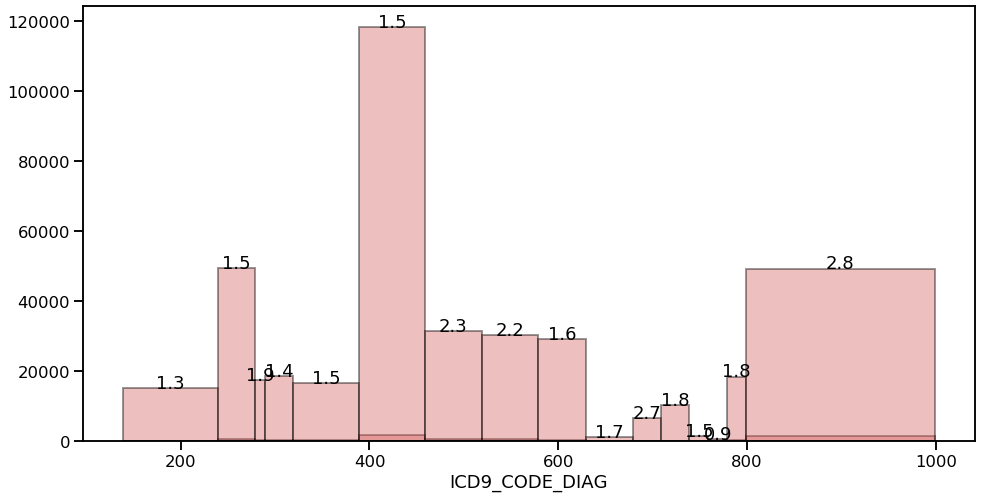

```python
diag_bins = [139, 239, 279, 289, 319, 389, 459, 519, 579, 629, 679, 709, 739, 759, 779, 799, 999]

sns.set_context('talk')
f, ax = plt.subplots(figsize = (16,8))
sns.set_color_codes('muted')
sns.distplot(my_df.loc[my_df['lt_mortality'] == 1, 'ICD9_CODE_DIAG'], bins=diag_bins,
             color='r', kde=False, axlabel="Diagnosis Code", hist_kws=dict(edgecolor="black", linewidth=2))
sns.set_color_codes('muted')
sns.distplot(my_df['ICD9_CODE_DIAG'], bins=diag_bins, kde=False, color='r',
             hist_kws=dict(edgecolor="black", linewidth=2))

count = 0
death_array = [];
for p in ax.patches:
    _x = p.get_x() + p.get_width() / 2
    _y = p.get_y() + p.get_height()
    value = '{:}'.format(p.get_height())
    if count <= 15:
        death_array.append(value)
    else:
        value = 100 * float(death_array[count - 16]) / float(value)
        value = round(value, 1)
        ax.text(_x, _y, value, ha="center")
    count += 1
```

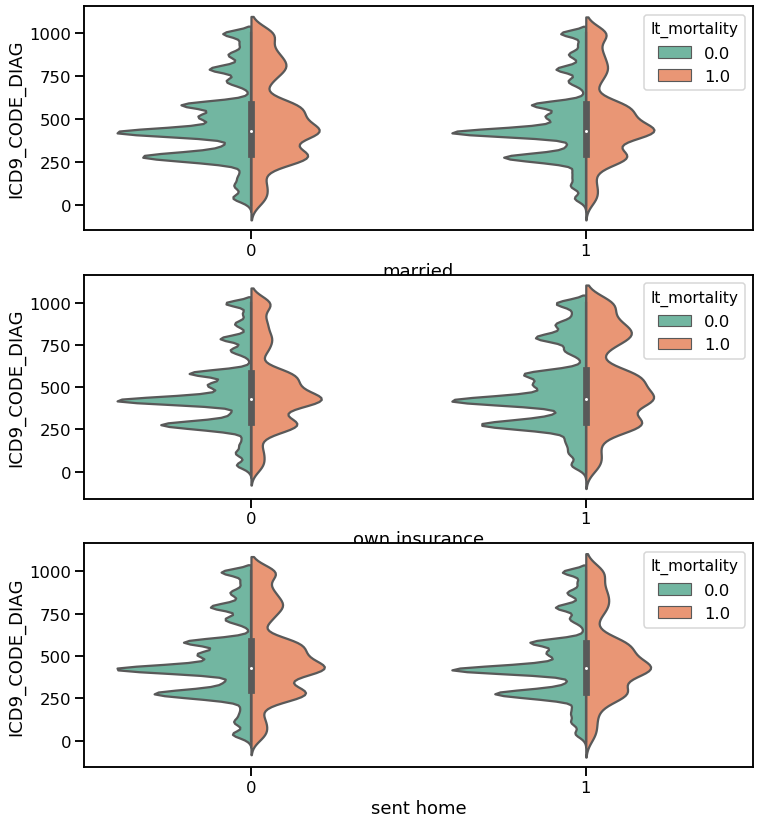

```python
sns.set_context('talk')
f, ax = plt.subplots(3, 1, figsize = (12,14))
sns.violinplot(x="married", y="ICD9_CODE_DIAG", hue="lt_mortality",
                    data=my_df, palette="Set2", split="True", ax = ax[0])
sns.violinplot(x="own insurance", y="ICD9_CODE_DIAG", hue="lt_mortality",
                    data=my_df, palette="Set2", split="True", ax = ax[1])
sns.violinplot(x="sent home", y="ICD9_CODE_DIAG", hue="lt_mortality",
                    data=my_df, palette="Set2", split="True", ax = ax[2])
```

### Procedures

Procedures also follow a similar coding convention to diagnoses. What may be more interesting, however, is the amount of procedures that a patient undergoes, and seeing if there is a correlation between this and the long term mortality rate.

```
Mean without Death: 5.141268836501831
Mean with Death: 14.445309603262885
```

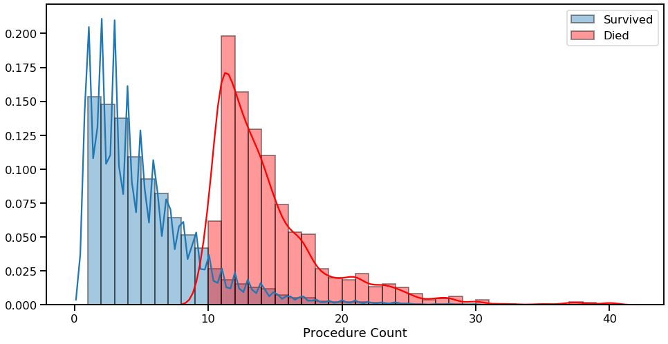

```python
proc_bins = np.arange(40)

sns.set_context('talk')
f, ax = plt.subplots(figsize = (16,8))
sns.distplot(my_df.loc[my_df['lt_mortality'] == 0, 'SEQ_NUM_PROC'], bins=proc_bins,
             hist_kws=dict(edgecolor="black", linewidth=2), label="Survived")
print(f"Mean without Death: {my_df.loc[my_df['lt_mortality'] == 0, 'SEQ_NUM_PROC'].mean()}")
sns.distplot(my_df.loc[my_df['lt_mortality'] == 1, 'SEQ_NUM_PROC'], bins=proc_bins, color='red',
             axlabel = "Procedure Count", hist_kws=dict(edgecolor="black", linewidth=2),
             label="Died")
print(f"Mean with Death: {my_df.loc[my_df['lt_mortality'] == 1, 'SEQ_NUM_PROC'].mean()}")

ax.legend()
```

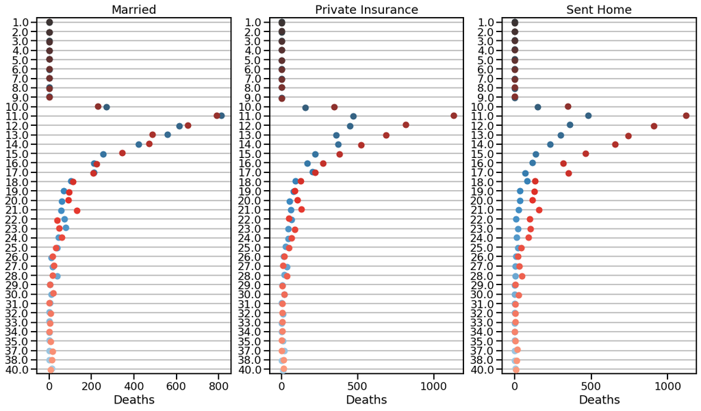

```python
plot_cols = ['lt_mortality', 'SEQ_NUM_PROC', 'dead_married', 'dead_insurance', 'dead_home']
plot_df = pd.DataFrame(columns = plot_cols)
plot_df[['lt_mortality', 'SEQ_NUM_PROC']] = my_df[['lt_mortality', 'SEQ_NUM_PROC']]

plot_df['dead_married'] = my_df['lt_mortality'] + my_df['married']
plot_df['dead_insurance'] = my_df['lt_mortality'] + my_df['own insurance']
plot_df['dead_home']= my_df['lt_mortality'] + my_df['sent home']
plot_df['dead_married'] = (plot_df['dead_married'] == 2)
plot_df['dead_insurance'] = (plot_df['dead_insurance'] == 2)
plot_df['dead_home'] = (plot_df['dead_home'] == 2)

plot_df['dead_not_married'] = (plot_df['lt_mortality'] - plot_df['dead_married'])
plot_df['dead_not_insurance'] = (plot_df['lt_mortality'] - plot_df['dead_insurance'])
plot_df['dead_not_home'] = (plot_df['lt_mortality'] - plot_df['dead_home'])

final_plot_df = plot_df.groupby(['SEQ_NUM_PROC'], as_index=False).sum()

sns.set_context('talk')
f, ax = plt.subplots(1, 3, figsize = (18,10))

positive = ['dead_married', 'dead_insurance', 'dead_home']
negative = ['dead_not_married', 'dead_not_insurance', 'dead_not_home']

for i in range(3):
    sns.stripplot(y=final_plot_df['SEQ_NUM_PROC'], x=final_plot_df[positive[i]], size=10, orient="h",
          palette="Blues_d", linewidth=0, ax = ax[i])

for i in range(3):
    sns.stripplot(y=final_plot_df['SEQ_NUM_PROC'], x=final_plot_df[negative[i]], size=10, orient="h",
          palette="Reds_d", linewidth=0, ax = ax[i])

titles = ["Married", "Private Insurance", "Sent Home"]

for ax, title in zip(ax.flat, titles):

    ax.set(title=title, xlabel="Deaths", ylabel="")
    ax.xaxis.grid(False)
    ax.yaxis.grid(True)
```

## Neural Network

A neural network was created to predict long term mortality. For each encounter, there will be information about the amount of procedures, types of diagnoses, marital status, insurance status, and whether or not that patient was sent home after their stay in the hospital. Additionally, there is one more column designating whether or not that patient died within one year of being discharged.

## Step 1

Bucket the ICD codes for diagnoses to create categories.

```python
my_df.head()
```

|  | SUBJECT_ID | HADM_ID | MARITAL_STATUS | INSURANCE | DISCHARGE_LOCATION | SEQ_NUM_PROC | ICD9_CODE_PROC | PROC_NAME | SEQ_NUM_DIAG | ICD9_CODE_DIAG | DIAG_NAME | lt_mortality | married | own insurance | sent home | ICD9_BUCKET |
| --- | --- | --- | --- | --- | --- | --- | --- | --- | --- | --- | --- | --- | --- | --- | --- | --- |
| 0 | 24810 | 143994 | MARRIED | Private | HOME HEALTH CARE | 40.0 | 9729.0 | Non-op replacement NEC | 1.0 | 533 | Ac peptic ulc w perf-obs | 0.0 | 1 | 1 | 1 | 520.0 |
| 1 | 24810 | 143994 | MARRIED | Private | HOME HEALTH CARE | 40.0 | 9729.0 | Non-op replacement NEC | 2.0 | 995 | SIRS, NOS | 0.0 | 1 | 1 | 1 | 800.0 |
| 2 | 24810 | 143994 | MARRIED | Private | HOME HEALTH CARE | 40.0 | 9729.0 | Non-op replacement NEC | 3.0 | 567 | Peritonitis NOS | 0.0 | 1 | 1 | 1 | 520.0 |
| 3 | 24810 | 143994 | MARRIED | Private | HOME HEALTH CARE | 40.0 | 9729.0 | Non-op replacement NEC | 4.0 | 452 | Portal vein thrombosis | 0.0 | 1 | 1 | 1 | 390.0 |
| 4 | 24810 | 143994 | MARRIED | Private | HOME HEALTH CARE | 40.0 | 9729.0 | Non-op replacement NEC | 5.0 | 567 | Retroperiton abscess NEC | 0.0 | 1 | 1 | 1 | 520.0 |

## Step 2

Merge the buckets into the data, and remove nonrelevant information.

```python
final_data = my_df[['SEQ_NUM_PROC', 'ICD9_BUCKET', 'married',
                    'own insurance', 'sent home', 'lt_mortality']]
final_data.head()
```

|  | SEQ_NUM_PROC | ICD9_BUCKET | married | own insurance | sent home | lt_mortality |
| --- | --- | --- | --- | --- | --- | --- |
| 0 | 40.0 | 520.0 | 1 | 1 | 1 | 0.0 |
| 1 | 40.0 | 800.0 | 1 | 1 | 1 | 0.0 |
| 2 | 40.0 | 520.0 | 1 | 1 | 1 | 0.0 |
| 3 | 40.0 | 390.0 | 1 | 1 | 1 | 0.0 |
| 4 | 40.0 | 520.0 | 1 | 1 | 1 | 0.0 |

## Step 3

Categorize the data by assigning numerical labels to each of the values.

```python
categorical_data[:10]
```

```
tensor([[ 8.,  1.,  1.,  1., 37.],
        [16.,  1.,  1.,  1., 37.],
        [ 8.,  1.,  1.,  1., 37.],
        [ 6.,  1.,  1.,  1., 37.],
        [ 8.,  1.,  1.,  1., 37.],
        [ 8.,  1.,  1.,  1., 37.],
        [ 2.,  1.,  1.,  1., 37.],
        [ 2.,  1.,  1.,  1., 37.],
        [ 8.,  1.,  1.,  1., 37.],
        [ 8.,  1.,  1.,  1., 37.]])
```

## Step 4

Split the data into a training set and a testing set.

## Step 5

Create the network.

```python
print(model)
```

```
Mortality_Predict(
  (layer_1): Linear(in_features=5, out_features=10, bias=True)
  (relu1): ReLU()
  (batchnorm1): BatchNorm1d(10, eps=1e-05, momentum=0.1, affine=True, track_running_stats=True)
  (layer_2): Linear(in_features=10, out_features=10, bias=True)
  (relu2): ReLU()
  (batchnorm2): BatchNorm1d(10, eps=1e-05, momentum=0.1, affine=True, track_running_stats=True)
  (dropout): Dropout(p=0.4, inplace=False)
  (layer_out): Linear(in_features=10, out_features=1, bias=True)
)
```

## Step 6

Train the model. It was trained over 50 epochs, with a batch size of 128.

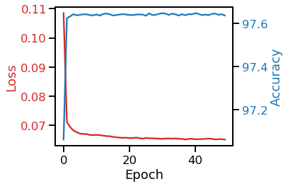

```python
fig, ax1 = plt.subplots()

color = 'tab:red'
ax1.set_xlabel('Epoch')
ax1.set_ylabel('Loss', color=color)
ax1.plot(loss_vector, color=color)
ax1.tick_params(axis='y', labelcolor=color)

ax2 = ax1.twinx()

color = 'tab:blue'
ax2.set_ylabel('Accuracy', color=color)
ax2.plot(acc_vector, color=color)
ax2.tick_params(axis='y', labelcolor=color)

fig.tight_layout()
```

## Step 7

Test and evaluate the model. Something is "true" if the result was guessed correctly, and "false" if not. Something is "positive" if the result was a 1, and "negative" if it was a 0.

- Recall - the ability to find all the relevant cases (everyone who will die within one year)

$\frac{TP}{TP + FN}$

- Precision - the ability to identity relevant data points (only who will die within one year)

$\frac{TP}{TP + FP}$

- Accuracy - total correct

$\frac{TP + TN}{Total}$

```python
print(classification_report(output_test_data, y_pred_list))
```

```
              precision    recall  f1-score   support

         0.0       1.00      1.00      1.00     73228

    accuracy                           1.00     73228
   macro avg       1.00      1.00      1.00     73228
weighted avg       1.00      1.00      1.00     73228
```